# Using `riding_binplot` to create tile grid maps

Andrew McCormack

2019-05-08

## Description

The `riding_binplot()` function takes data at the federal riding level as its input and creates a tile grid map to visualize these data with `ggplot2`.

## Overview

Although Canada is a very large country, around 80% of its population is concentrated in urban areas. Because of this, the majority of federal electoral ridings are small and urban while a much smaller number of ridings in sparsely-populated regions account for the majority of Canada’s landmass. Because of this, visualizing statistics at the riding level with standard cloropeth maps is not ideal. The `riding_binplot()` function of the `mapcan` package offers an alternative: the tile grid map. Inspired by the `statebins` package (Rudis 2017), federal riding tile grid maps are a way of visualizing riding-level data when it is not neccessary to accurately represent the ridings geographically.

## Using `riding_binplot()`

### Categorical variables

#### Preparing the data

`riding_binplot()` requires a data frame that includes a riding-level variable as well as numeric riding code variable. Specify the riding-level variable of interest in the `value_col` argument. Specify the numeric riding code variable in the `riding_col` argument. For instance, we may want to create a tile plot for the seat distribution of the 2015 federal election.

Luckily, `mapcan` comes with built-in federal election data (the `federal_election_results` data frame) that dates back to 1996 with variables for riding codes/names, provinces, population, voter turnout and the winning party for each riding. Let’s restrict `federal_election_results` to include only observations (ridings) from the 2015 election. Because we only need (1) a riding characteristic variable and (2) a riding code variable, we can select only these columns from the data.

```r
fed_2015 <- federal_election_results %>%
  filter(election_year == 2015) %>%
  dplyr::select(riding_code, party)
```

*Note: We remove all irrelevant variables from the data frame to illustrate more clearly how `riding_binplot` operates. They do not need to be removed in practice.*

This new data frame has the two columns that we need: one to specify the riding code (`riding_code`) and another to specify a riding-level characteristic of interest (`party`). Let’s look at a sample:

```r
fed_2015 %>%
  sample_n(10)
```

```
#>    riding_code   party
#> 1        24024 Liberal
#> 2        59009     NDP
#> 3        24072 Liberal
#> 4        59008 Liberal
#> 5        10005 Liberal
#> 6        24026 Liberal
#> 7        35007 Liberal
#> 8        35042 Liberal
#> 9        35052 Liberal
#> 10       48014 Liberal
```

Looking good.

#### Plotting the data

Use `continuous = TRUE` for continuous variables and `continuous = FALSE` for categorical variables. `party` is a categorical variable, so we will specify `continuous = FALSE`:

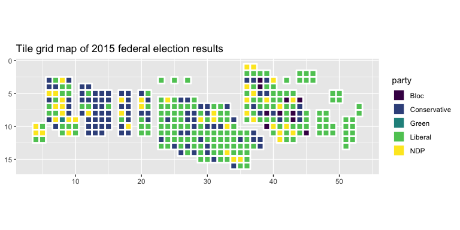

```r
fed_2015_bins <- fed_2015 %>%
  riding_binplot(value_col = party,
                 continuous = FALSE) +
  ggtitle("Tile grid map of 2015 federal election results")
fed_2015_bins
```

You will notice that the axis text has no substantive significance (it just the coordinates of the tiles). You can remove it, along with the axis ticks and background grid using `theme_mapcan` function, a `ggplot` theme that is part of the `mapcan` package.

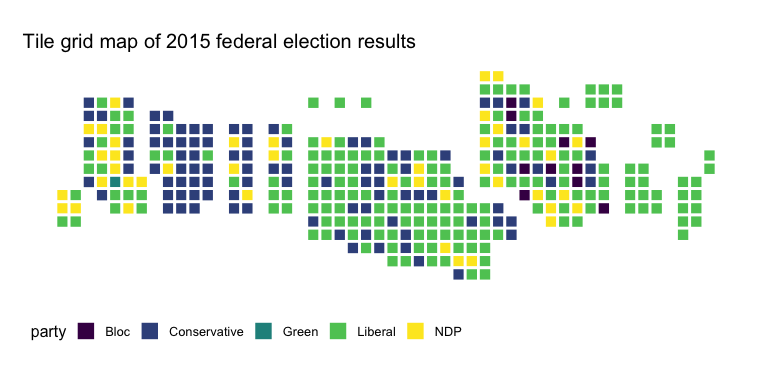

```r
fed_2015_bins <- fed_2015_bins +
  theme_mapcan()

fed_2015_bins
```

You will also notice that the colours provided by default from `riding_binplot` are not ideal for a tile plot with Canadian political parties. Because `riding_binplot` simply creates a `ggplot` object, we can override the `riding_binplot` scale and add our own:

```r
fed_2015_bins +
  scale_fill_manual(name = "Party",
                    values = c("mediumturquoise", "blue", "springgreen3", "red", "orange"))
```

[output not shown]

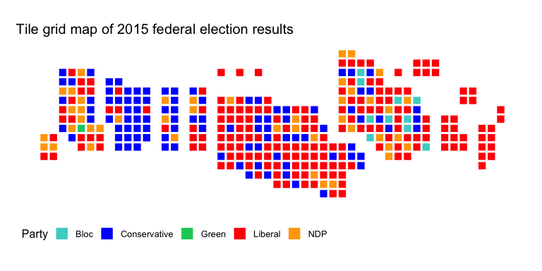

In this tile grid map, tiles are arranged by province yet, because seats are highly concentrated in urban areas, each tile only roughly corresponds to geographic location of the riding it represents. The `arrange = TRUE` option provides a better representation of the disribution of variables within provinces when the exact location of the riding is not relevant.

[output not shown]

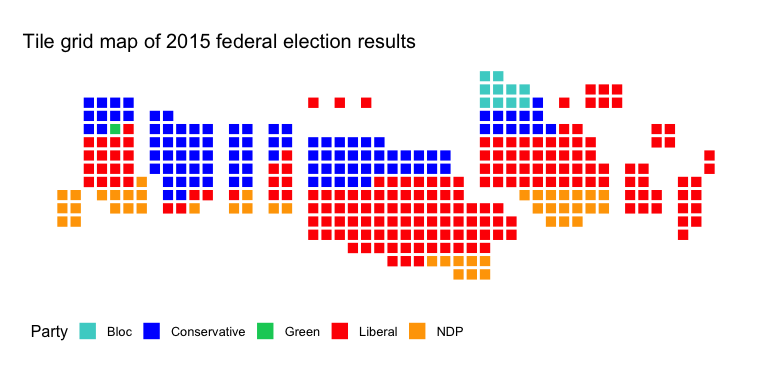

```r
fed_2015 %>%
  riding_binplot(value = party,
                 continuous = FALSE,
                 arrange = TRUE) +
  theme_mapcan() +
  scale_fill_manual(name = "Party",
                    values = c("mediumturquoise", "blue", "springgreen3", "red", "orange")) +
  ggtitle("Tile grid map of 2015 federal election results")
```

Compared to a standard cloropeth map, the tile grid map gives us a better sense of how the 2015 federal election shaped up:

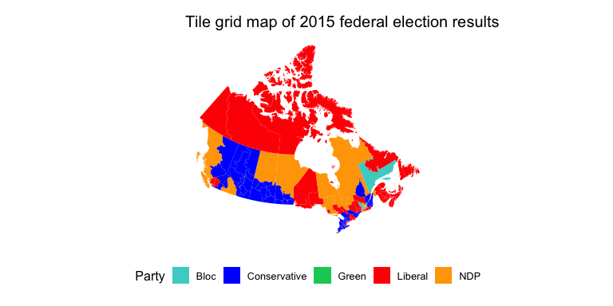

```r
fed_2015_cloropleth <- mapcan(boundaries = ridings, type = standard)

left_join(fed_2015_cloropleth, fed_2015, by = "riding_code") %>%
  ggplot(aes(long, lat, group = group, fill = party)) +
  geom_polygon() +
  coord_fixed() +
  scale_fill_manual(name = "Party",
                    values = c("mediumturquoise", "blue", "springgreen3", "red", "orange")) +
  ggtitle("Tile grid map of 2015 federal election results") +
  theme_mapcan()
```

### Continuous variables

Let’s make a riding tile plot with a continuous variable: voter turnout. This variable is included in the `federal_election_results` dataset, which is part of the `mapcan` package. Specify `continuous = TRUE` in riding_binplot so that ggplot uses a continuous fill scale. The default scale is `scale_fill_viridis_c()` from the `viridis` package. Though, as demonstrated above, this can be changed easily by overriding the default scale.

Note that the data can be tidied up using `dplyr` and piped directly into `riding_binplot()`:

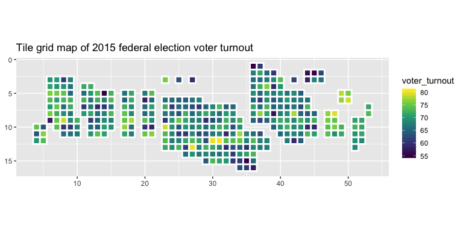

```r
federal_election_results %>%
  filter(election_year == 2015) %>%
  riding_binplot(value = voter_turnout,
                 continuous = TRUE) +
  ggtitle("Tile grid map of 2015 federal election voter turnout")
```

Once again, because we care little about the axis grid and axis values, we can use the `theme_mapcan()` theme:

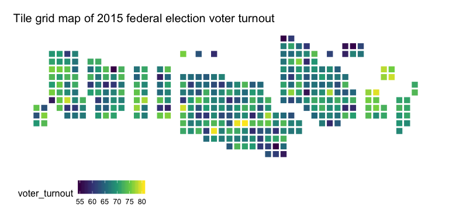

```r
federal_election_results %>%
  filter(election_year == 2015) %>%
  riding_binplot(value = voter_turnout,
                 continuous = TRUE) +
  theme_mapcan() +
  ggtitle("Tile grid map of 2015 federal election voter turnout")
```

Like with the election results that are plotted above, we may want to arrange the values of voter turnout within provinces. Fortunately, we can also use the `arrange = TRUE` argument when the riding-level variable is continuous.

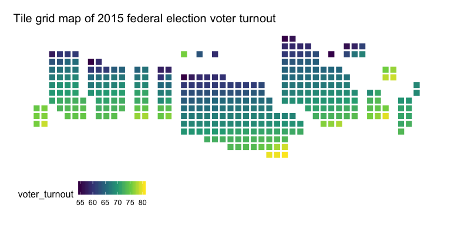

```r
federal_election_results %>%
  filter(election_year == 2015) %>%
  riding_binplot(value = voter_turnout,
                 continuous = TRUE,
                 arrange = TRUE) +
  theme_mapcan() +
  ggtitle("Tile grid map of 2015 federal election voter turnout")
```

If squares are not your jam, you can also use hexagons with the `shape = hexagon` argument. Note that the default is `shape = square`.

[figure not shown]

```r
federal_election_results %>%
  filter(election_year == 2015) %>%
  riding_binplot(value = voter_turnout,
                 continuous = TRUE,
                 arrange = TRUE,
                 shape = "hexagon") +
  theme_mapcan() +
  ggtitle("Hexagon grid map of 2015 federal election voter turnout")
```

### Provincial ridings

Currently, only Quebec provincial ridings can be plotted with `riding_binplot()`. In the near future, `riding_binplot()` will be able to create bin plots for the other provinces.

To create a provincial riding plot, specify `provincial = TRUE` (to let riding_binplot know that it is provincial ridings you wish to plot) and `province = QC` for Quebec.

[output not shown]

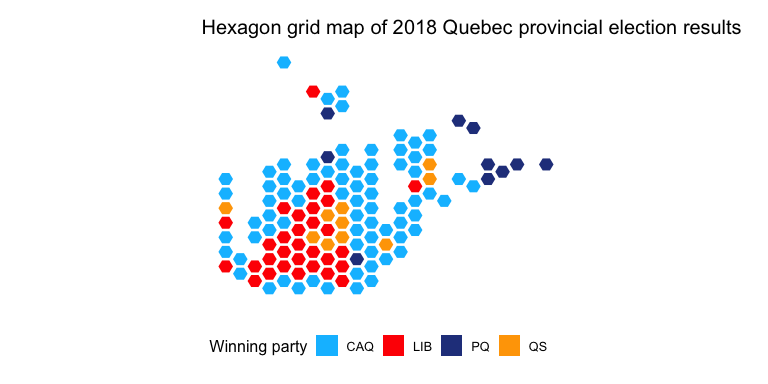

```r
riding_binplot(quebec_provincial_results,
               value_col = party,
               riding_col = riding_code,
               continuous = FALSE,
               provincial = TRUE,
               province = QC,
               shape = "hexagon") +
  theme_mapcan() +
  scale_fill_manual(name = "Winning party",
                    values = c("deepskyblue1", "red","royalblue4",  "orange")) +
  ggtitle("Hexagon grid map of 2018 Quebec provincial election results")
```

## Reference

Rudis, Bob. 2017. *Statebins: Create ’U.s.’ Uniform Square State Cartogram Heatmaps*. https://github.com/hrbrmstr/statebins.